# Bayesian Cluster Analysis: Point Estimation and Credible Balls

Stephen Coleman

19/05/2020

NOT MY WORDS

## Summary

- Bayesian nonparametric models provide a posterior over the entire space of partitions.
- In a Bayesian analysis, the posterior of a real-valued parameter of interest is often summarized by reporting a point estimate such as the posterior mean along with 95% credible intervals to characterize uncertainty.
- This paper attempts to develop appropriate point estimates and credible sets to summarize the posterior of the clustering structure based on decision and information theoretic techniques

# Introduction

The expectation-maximization (EM) algorithm is typically used for maximum likelihood estimation (MLE) of the mixture model parameters. Given the MLEs of the parameters,the posterior probability that a data point belongs to a class can be computed through Bayes rule.

The cluster assignment of the data point corresponds to the class with maximal posterior probability, with the corresponding posterior probability reported as a measure of uncertainty. Importantly, however, this measure of uncertainty ignores uncertainty in the parameter estimates.

As opposed to MLE, Bayesian mixture models incorporate prior information on the parameters and allow one to assess uncertainty in the clustering structure unconditional on the parameter estimates.

Bayesian nonparametric mixture models assume that the number of components is infinite. As opposed to finite mixture models, this not only avoids specification of the number of components but also allows the number of clusters present in the data to grow unboundedly as more data is collected.

Bayesian nonparametric mixture models induce a random partition model (Quintana 2006) of the data points into clusters, and the posterior of the random partition reflects our belief and uncertainty of the clustering structure given the data.

Questions:

1. what is an appropriate point estimate of the clustering structure given the posterior?
2. how to summarise the uncertainty about this point estimate?

Often the first question one asks is what is an appropriate point estimate of the clustering structure based on the posterior. Such a point estimate is useful for concisely representing the posterior and often needed in applications.

Moreover, a characterization of the uncertainty around this point estimate would be desirable in many applications.

## Ordering partitions

The next properties involve first viewing the space of partitions as a partially ordered set. In particular, consider the space of partitions $C$ and the binary relation $\leq$ on $C$ defined by set containment, i.e. for $c,c' \in C$, $c \leq c'$ if for all $i = 1, \ldots, k_N$, $C_i \subseteq C'_j$ for some $j\in \{1, \ldots, k'_N\}$. The partition space $C$ equipped with $\leq$ is a partially ordered set. For any $c,c' \in C$, $c$ is covered by $c'$, denoted $c \prec c'$, if $c < c'$and there is no $\hat{c} \in C$ such that $c < \hat{c} < c'$. This covering relation is used to define the Hasse diagram, where the elements of $C$ are represented as nodes of a graph and a line is drawn from $c$ up to $c'$ when $c \prec c'$.

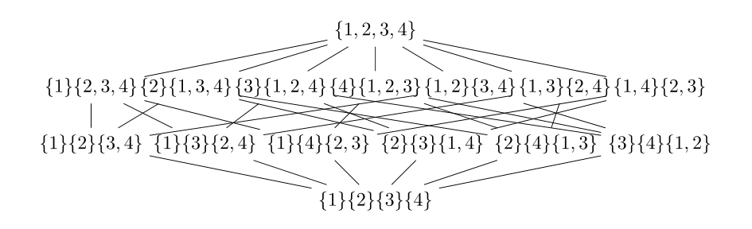

Example of a Hasse diagram for the semi-ordered set of partitions for 4 items, from Wade, Ghahramani, and others (2018).

## Point estimate

Could use the mode! Need to be able to compute marginal likelihood and the prior in closed form. Not always the case.

More generally,the posterior mode can be found by reporting the partition visited most frequently in the sampler. There’s issues with this as different partitions might be visited and so any specific partition might never have a frequency exceeding 1.

However,it is well-known that the mode can be unrepresentative of the center of a distribution.

Alternative methods involve using the PSM, see Fritsch, Ickstadt, and others (2009) for a detailed description of many such methods.

Could use decision theory and a defined loss function. We would like a loss function that can account for similarity between clusterings. Binder’s loss (Binder 1978) is the classic go-to, but Wade, Ghahramani, and others (2018) go to the *variation of information* proposed by Meilă (2007).

This measures the amount of information lost and gained in changing from clustering to clustering.

Both the variation ofinformation and Binder’s loss possess the desirable properties of being metrics on the space of partitions and being *aligned* with the lattice of partitions. Whatever that means.

It ends up it means it’s a metric on the Hasse diagram.

From decision theory, a point estimate is obtained by specifying a loss function, $L(c', c)$, which measures the loss of estimating the true clustering $c$ with $c'$. Since the true clustering is unknown, the loss is averaged across all possible true clusterings, where the loss associated to each potential true clustering is weighted by its posterior probability.

The point estimate, $c^*$, corresponds to the estimate which minimizes the posterior expected loss:

$$\begin{align}
c^* = \underset{c'}{\operatorname{argmin}} \mathbb{E}[L(c', c) | X] = \underset{c'}{\operatorname{argmin}} \sum_c L(c', c)p (c | X)
\end{align}$$

Constructing a general loss function is not straightforward because, as pointed out by Binder (1978), the loss function should satisfy basic principles such as invariance to permutations of the data point indices and invariance to permutations of the cluster labels for both the true and estimated clusterings. From this, he developed a loss function based around the Rand Index.

### Algorithm

- greedy search
- based upon the Hasse diagram (using either VI or B)
- given some partition $c'$, we consider the $l$ closest partitions that cover $c'$ and the $l$ closest partitions that $c'$ covers ($2l + 1$ partitions).
- the distance used to determine the closest partitions corresponds to the selected loss of $VI$ or $B$.
- the posterior expected loss, $\mathbb{E}[L(c,\hat{c})|X]$ is computed for all proposed partitions $\hat{c}$, and we move in the direction of minimum posterior expected loss, that is the partition $c'$ with minimal $\mathbb{E}[L(c,c')|X]$ is selected.
- the algorithm stops after a local minimum is found or a given number of iterartions have passed.
- recommend multiple restarts (local minima), for example, at different MCMC samples or the best partition found by other search algorithms.
- a larger value of $l$ will allow more exploration and reduce the need for multiple restarts
- default value of $l=2N$ as this showed good exploration in the examples considered with little sensitivity to the initial value of $c'$. However, for larger datasets, this may be too expensive and multiple restarts withsmaller $l$ may be preferred

NOTE: An advantage of the greedy search algorithm over simply restricting to partitions visited in the chain is that partitions not explored in the MCMC algorithm can be considered (similarly to `maxpear` from Fritsch, Ickstadt, and others 2009); in fact, in almost all simulated and real examples, the clustering estimate is not among the sampled partitions and results in a lower expected loss than any sampled partition.

## References

Binder, David A. 1978. “Bayesian Cluster Analysis.” *Biometrika* 65 (1): 31–38.

Fritsch, Arno, Katja Ickstadt, and others. 2009. “Improved Criteria for Clustering Based on the Posterior Similarity Matrix.” *Bayesian Analysis* 4 (2): 367–91.

Meilă, Marina. 2007. “Comparing Clusterings—an Information Based Distance.” *Journal of Multivariate Analysis* 98 (5): 873–95.

Quintana, Fernando A. 2006. “A Predictive View of Bayesian Clustering.” *Journal of Statistical Planning and Inference* 136 (8): 2407–29.

Wade, Sara, Zoubin Ghahramani, and others. 2018. “Bayesian Cluster Analysis: Point Estimation and Credible Balls (with Discussion).” *Bayesian Analysis* 13 (2): 559–626.